# Background

We’re going to explore a large data set or traffic crashes to learn about what factors are connected with injuries. We will use data from the city of [Chicago’s open data portal](https://data.cityofchicago.org/Transportation/Traffic-Crashes-Crashes/85ca-t3if/about_data). (This activity is derived from a [blog post](https://juliasilge.com/blog/chicago-traffic-model/) by Julia Silge)

```r
years_ago <- mdy("01/01/2022") # data from last 2 years. May take time to load!
crash_url <- glue::glue("https://data.cityofchicago.org/Transportation/Traffic-Crashes-Crashes/85ca-t3if?$where=CRASH_DATE >= '{years_ago}'")
crash_raw <- as_tibble(read.socrata(crash_url)) # a new way to read in data, don't worry about it!
```

This dataset is pretty crazy! Take a look at it in the viewer, and then let’s do some data munging to get it into a nicer form.

-create a variable called `injuries` which indicates if the crash involved injuries or not. -create an unknown category for missing `report_type`s -decide which other variables to keep

```r
crash <- crash_raw %>%
  arrange(desc(crash_date)) %>%
  transmute(
    injuries = as.factor(if_else(injuries_total > 0, "injuries", "none")),
    longitude, latitude, lighting_condition, weather_condition, device_condition, traffic_control_device, first_crash_type, roadway_surface_cond, prim_contributory_cause, sec_contributory_cause, crash_month, crash_date, posted_speed_limit
  )
```

###Question 1

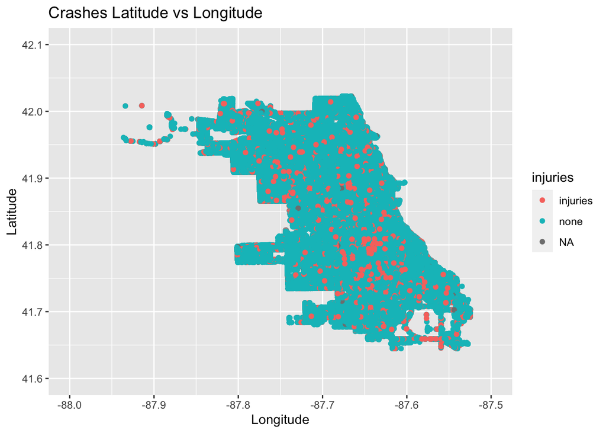

```r
ggplot(data = crash, aes(x=longitude, y=latitude, color= injuries))+
  geom_point()+
  xlab("Longitude") +
  ylab("Latitude") +
  xlim(-88, -87.5) +
  ylim(41.6, 42.1) +
  ggtitle("Crashes Latitude vs Longitude")
```

###Question 2

```r
freq_table <- table(crash$ prim_contributory_cause)
print(freq_table)
```

```
##
##                                                                           ANIMAL
##                                                                              192
##                                           BICYCLE ADVANCING LEGALLY ON RED LIGHT
##                                                                                7
##                                                CELL PHONE USE OTHER THAN TEXTING
##                                                                              265
##                                                 DISREGARDING OTHER TRAFFIC SIGNS
##                                                                              468
##                                                       DISREGARDING ROAD MARKINGS
##                                                                              206
##                                                           DISREGARDING STOP SIGN
##                                                                             2183
##                                                     DISREGARDING TRAFFIC SIGNALS
##                                                                             4703
##                                                          DISREGARDING YIELD SIGN
##                                                                               55
##                                                DISTRACTION - FROM INSIDE VEHICLE
##                                                                             1352
##                                               DISTRACTION - FROM OUTSIDE VEHICLE
##                                                                              771
##      DISTRACTION - OTHER ELECTRONIC DEVICE (NAVIGATION DEVICE, DVD PLAYER, ETC.)
##                                                                               98
##                                                  DRIVING ON WRONG SIDE/WRONG WAY
##                                                                             1397
##                                              DRIVING SKILLS/KNOWLEDGE/EXPERIENCE
##                                                                             8441
##                                                    EQUIPMENT - VEHICLE CONDITION
##                                                                             1315
##                                EVASIVE ACTION DUE TO ANIMAL, OBJECT, NONMOTORIST
##                                                                              382
##                                           FAILING TO REDUCE SPEED TO AVOID CRASH
##                                                                             8875
##                                                    FAILING TO YIELD RIGHT-OF-WAY
##                                                                            24905
##                                                            FOLLOWING TOO CLOSELY
##                                                                            18929
##                                  HAD BEEN DRINKING (USE WHEN ARREST IS NOT MADE)
##                                                                              192
##                                                                 IMPROPER BACKING
```

[output cut: 22 more lines]

```
##                                                                              371
##                                         ROAD ENGINEERING/SURFACE/MARKING DEFECTS
##                                                                              463
##                                                                          TEXTING
##                                                                               60
##                                                             TURNING RIGHT ON RED
##                                                                              197
##                                                              UNABLE TO DETERMINE
##                                                                            94317
##               UNDER THE INFLUENCE OF ALCOHOL/DRUGS (USE WHEN ARREST IS EFFECTED)
##                                                                              802
##                             VISION OBSCURED (SIGNS, TREE LIMBS, BUILDINGS, ETC.)
##                                                                             1161
##                                                                          WEATHER
##                                                                             3060
```

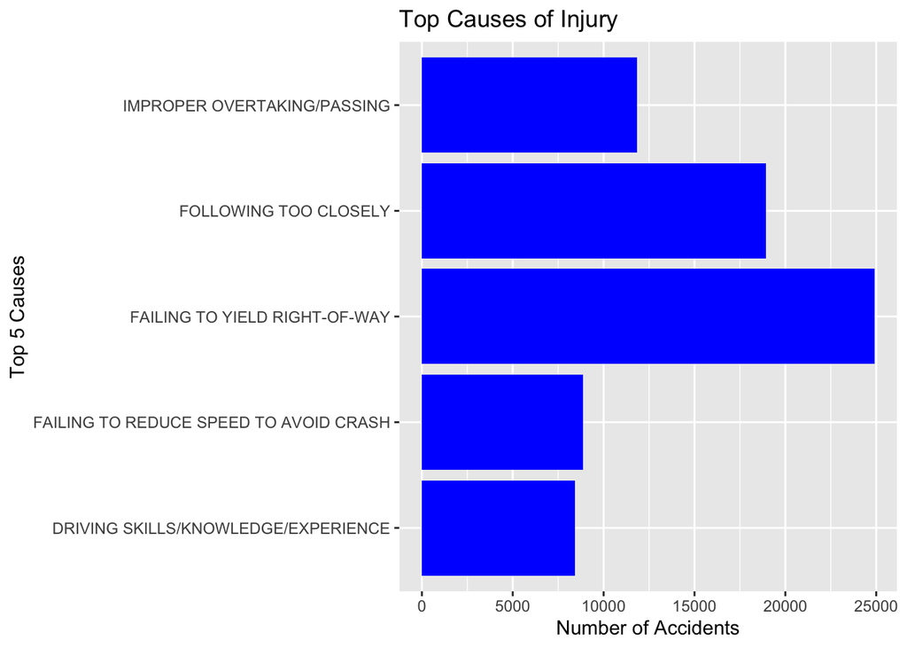

```r
crash_top <- crash %>% filter(prim_contributory_cause=="IMPROPER OVERTAKING/PASSING" | prim_contributory_cause == "FOLLOWING TOO CLOSELY" | prim_contributory_cause == "FAILING TO YIELD RIGHT-OF-WAY" | prim_contributory_cause == "FAILING TO REDUCE SPEED TO AVOID CRASH" | prim_contributory_cause == "DRIVING SKILLS/KNOWLEDGE/EXPERIENCE")
ggplot(data = crash_top, aes(y=prim_contributory_cause))+
  geom_bar(fill = "blue")+
  theme(axis.text.y = element_text(angle = 0, hjust = 1)) +
  xlab("Number of Accidents") +
  ylab("Top 5 Causes") +
  labs(title="Top Causes of Injury")
```

###Question 3

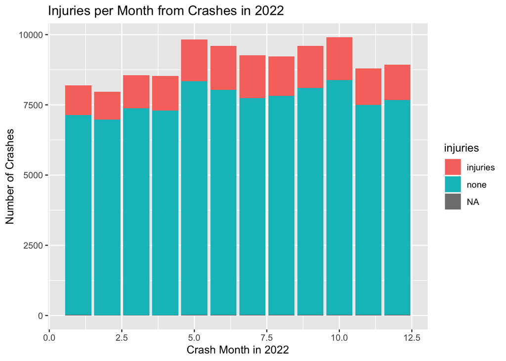

```r
crash$Year <- year(crash$crash_date)
crash_2022<- crash %>% filter(Year == "2022")
crash_2023<- crash %>% filter(Year == "2023")
ggplot(data = crash_2022, aes(x=crash_month, fill = injuries))+
 geom_bar() +
  xlab("Crash Month in 2022") +
  ylab("Number of Crashes") +
   labs(title = "Injuries per Month from Crashes in 2022")
```

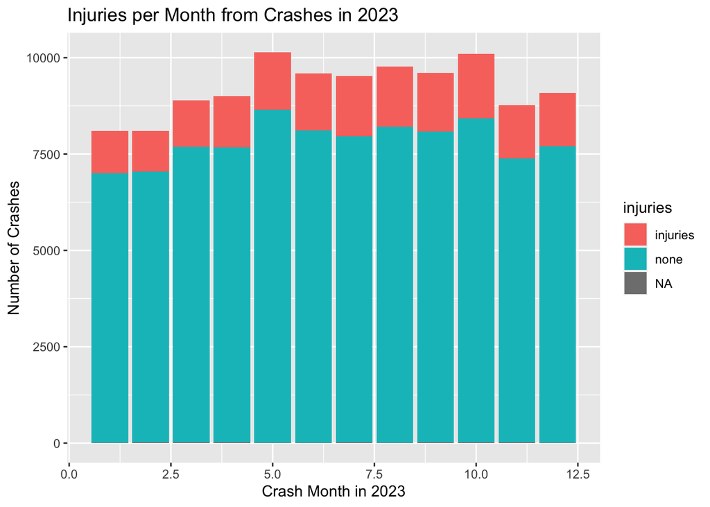

```r
ggplot(data = crash_2023, aes(x=crash_month, fill = injuries))+
 geom_bar() +
    xlab("Crash Month in 2023") +
  ylab("Number of Crashes") +
  labs(title = "Injuries per Month from Crashes in 2023")
```

###Question 4

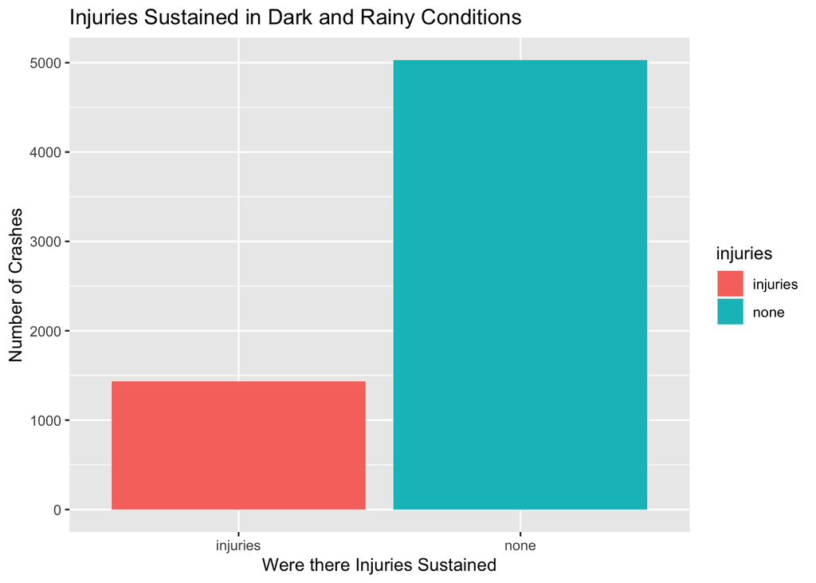

```r
crash_rainy <- crash %>% filter(weather_condition == "RAIN" |  weather_condition == "FREEZING RAIN/DRIZZLE")
crash_darkandrainy <- crash_rainy %>% filter(lighting_condition == "DARK" | lighting_condition == "DARKNESS, LIGHTED ROAD")
crash_darkandrainy <- crash_darkandrainy %>% filter(injuries != "N/A")

ggplot(data = crash_darkandrainy, aes(x=injuries, fill=injuries)) +
  geom_bar() +
  xlab("Were there Injuries Sustained") +
  ylab("Number of Crashes") +
  labs(title = "Injuries Sustained in Dark and Rainy Conditions")
```

###Question 5

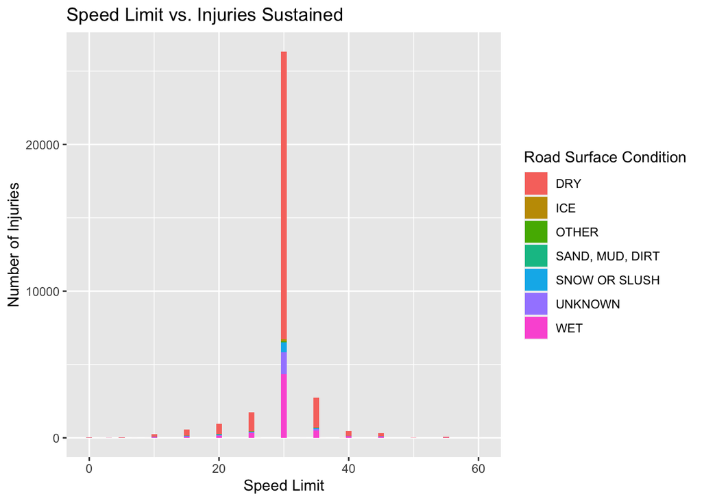

```r
crash_speed <- crash %>% filter(injuries == "injuries")
ggplot(data = crash_speed, aes(x=posted_speed_limit, fill=roadway_surface_cond)) +
  geom_bar() +
  xlab("Speed Limit") +
  ylab("Number of Injuries") +
  labs(fill="Road Surface Condition", title = "Speed Limit vs. Injuries Sustained")
```

## Exploratory Data Analysis

Here’s a few questions to get you started.

1. Take a look at crashes by latitude and longitude, colored by injuries. What do you notice?
2. What are the most common contributing factors to a crash?
3. How do crashes vary month by month? Compare crashes by month in 2022 to 2023.
4. Are crashes more likely to cause injuries when it is rainy and dark? Use the variables `weather_condition` and `lighting_condition` to explore.
5. Choose a question you want to explore, and create an appropriate visual.